# EP09: Regresión Lineal Múltiple

Equipo 3

2025-06-02

## Contexto de la actividad

> Un estudio recolectó medidas anatómicas de 247 hombres y 260 mujeres (Heinz et al., 2003). El estudio incluyó nueve mediciones del esqueleto (ocho diámetros y una profundidad de hueso a hueso) y doce mediciones de grosor (circunferencias) que incluyen el tejido.

### Lectura de los datos

Se extraen los datos y se separan en conjuntos de entrenamiento y de prueba para la realización y posterior control de calidad de los modelos a confeccionar, donde se debe de excluir las variables de `Weight` y `Gender`.

```r
datos <- read.csv2("EP09 Datos.csv")

set.seed(1391)

# Sacar muestra aleatoria de tamaño 100 con Gender igual a 1 (hombres)
muestra <- datos[datos$Gender == 1, ] %>%
  sample_n(100)

# Separar la muestra en 70 y 30 datos
entrenamiento <- muestra[1:70, ]
prueba <- muestra[71:100, ]

# Obtener nombres de columnas excepto Weight y Gender
predictores_posibles <- setdiff(names(entrenamiento), c("Weight", "Gender"))
```

Luego, se eligen 8 predictores aletoriamente para armar el modelo RLM.

```r
# Seleccionar 8 predictores al azar
predictores_RLM <- sample(predictores_posibles, 8)
predictores_sobra <- setdiff(predictores_posibles, predictores_RLM)

entrenamiento_filtrado<- entrenamiento %>% select(all_of(predictores_sobra))
data_RLM<- entrenamiento %>% select(c(predictores_RLM,"Weight", "Shoulder.Girth"))

cat("Posibles predictores seleccionados para RLM:\n")
```

```
## Posibles predictores seleccionados para RLM:
```

```r
predictores_RLM
```

```
## [1] "Thigh.Girth"             "Waist.Girth"
## [3] "Chest.Girth"             "Bitrochanteric.diameter"
## [5] "Hip.Girth"               "Chest.diameter"
## [7] "Chest.depth"             "Age"
```

```
## Posibles predictores para RLS:
```

```
##  [1] "Biacromial.diameter" "Biiliac.diameter"    "Elbows.diameter"
##  [4] "Wrists.diameter"     "Knees.diameter"      "Ankles.diameter"
##  [7] "Shoulder.Girth"      "Navel.Girth"         "Bicep.Girth"
## [10] "Forearm.Girth"       "Knee.Girth"          "Calf.Maximum.Girth"
## [13] "Ankle.Minimum.Girth" "Wrist.Minimum.Girth" "Height"
```

```
## Correlación para cada variable respecto de Weight:
```

```
##                          [,1]
## Biacromial.diameter 0.4298733
## Biiliac.diameter    0.5699238
## Elbows.diameter     0.6290657
## Wrists.diameter     0.4945421
## Knees.diameter      0.4631815
## Ankles.diameter     0.4828497
## Shoulder.Girth      0.7819099
## Navel.Girth         0.7610077
## Bicep.Girth         0.7112530
## Forearm.Girth       0.7044929
## Knee.Girth          0.7006411
## Calf.Maximum.Girth  0.7573971
## Ankle.Minimum.Girth 0.6729261
## Wrist.Minimum.Girth 0.5970840
## Height              0.4948425
```

Dada la correlación medida, se selecciona como predictor para el RLS la variable “Shoulder.Girth”.

```r
RLS <- lm(Weight ~ Shoulder.Girth, data = entrenamiento)
summary(RLS)
```

```
##
## Call:
## lm(formula = Weight ~ Shoulder.Girth, data = entrenamiento)
##
## Residuals:
##     Min      1Q  Median      3Q     Max
## -14.730  -4.374  -1.027   3.948  20.711
##
## Coefficients:
##                Estimate Std. Error t value Pr(>|t|)
## (Intercept)    -59.1246    13.2463  -4.463 3.11e-05 ***
## Shoulder.Girth   1.1784     0.1139  10.343 1.35e-15 ***
## ---
## Signif. codes:  0 '***' 0.001 '**' 0.01 '*' 0.05 '.' 0.1 ' ' 1
##
## Residual standard error: 6.295 on 68 degrees of freedom
## Multiple R-squared:  0.6114, Adjusted R-squared:  0.6057
## F-statistic:   107 on 1 and 68 DF,  p-value: 1.351e-15
```

Se prepara un modelo máximo con todas las variables del dataset, y el modelo incial, que en este caso corresponde al RLS ya construido.

```r
RLM_max<- lm(Weight ~ ., data = data_RLM)

RLM <- step(RLS,scope=list(lower = RLS, upper = RLM_max), direction = "both", trace = "TRUE")
```

```
## Start:  AIC=259.53
## Weight ~ Shoulder.Girth
##
##                           Df Sum of Sq    RSS    AIC
## + Hip.Girth                1   1347.77 1346.8 212.99
## + Waist.Girth              1   1168.82 1525.7 221.72
## + Bitrochanteric.diameter  1    894.18 1800.4 233.31
## + Chest.depth              1    827.51 1867.0 235.85
## + Thigh.Girth              1    774.58 1920.0 237.81
## + Chest.Girth              1    704.68 1989.9 240.31
## + Chest.diameter           1    412.53 2282.0 249.90
## <none>                                 2694.6 259.53
## + Age                      1     73.25 2621.3 259.61
##
## Step:  AIC=212.99
## Weight ~ Shoulder.Girth + Hip.Girth
##
##                           Df Sum of Sq    RSS    AIC
## + Chest.depth              1    293.69 1053.1 197.77
## + Chest.Girth              1    219.93 1126.8 202.51
## + Waist.Girth              1    189.30 1157.5 204.38
## + Bitrochanteric.diameter  1    103.26 1243.5 209.40
## + Chest.diameter           1     64.79 1282.0 211.54
## + Thigh.Girth              1     41.93 1304.8 212.77
## <none>                                 1346.8 212.99
## + Age                      1      0.95 1345.8 214.94
## - Hip.Girth                1   1347.77 2694.6 259.53
##
## Step:  AIC=197.77
## Weight ~ Shoulder.Girth + Hip.Girth + Chest.depth
##
##                           Df Sum of Sq     RSS    AIC
## + Thigh.Girth              1    125.68  927.41 190.87
## + Chest.Girth              1     73.91  979.17 194.68
## + Age                      1     68.88  984.20 195.03
## + Bitrochanteric.diameter  1     44.94 1008.14 196.72
## + Chest.diameter           1     44.43 1008.66 196.75
## + Waist.Girth              1     38.43 1014.66 197.17
## <none>                                 1053.09 197.77
## - Chest.depth              1    293.69 1346.77 212.99
```

[output cut: 75 more lines]

```
##
## Step:  AIC=175.56
## Weight ~ Shoulder.Girth + Chest.depth + Thigh.Girth + Bitrochanteric.diameter +
##     Waist.Girth + Age + Chest.Girth
##
##                           Df Sum of Sq    RSS    AIC
## <none>                                 683.96 175.56
## - Chest.Girth              1    21.873 705.83 175.76
## + Hip.Girth                1    15.510 668.45 175.95
## + Chest.diameter           1     0.995 682.97 177.46
## - Age                      1   108.539 792.50 183.87
## - Bitrochanteric.diameter  1   127.697 811.66 185.54
## - Waist.Girth              1   135.749 819.71 186.23
## - Chest.depth              1   150.598 834.56 187.49
## - Thigh.Girth              1   250.662 934.62 195.41
```

```r
drop <- drop1(RLM, test = "F")
drop
```

```
## Single term deletions
##
## Model:
## Weight ~ Shoulder.Girth + Chest.depth + Thigh.Girth + Bitrochanteric.diameter +
##     Waist.Girth + Age + Chest.Girth
##                         Df Sum of Sq    RSS    AIC F value    Pr(>F)
## <none>                               683.96 175.56
## Shoulder.Girth           1    33.345 717.31 176.89  3.0227 0.0870729 .
## Chest.depth              1   150.598 834.56 187.49 13.6515 0.0004676 ***
## Thigh.Girth              1   250.662 934.62 195.41 22.7221 1.172e-05 ***
## Bitrochanteric.diameter  1   127.697 811.66 185.54 11.5755 0.0011751 **
## Waist.Girth              1   135.749 819.71 186.23 12.3054 0.0008466 ***
## Age                      1   108.539 792.50 183.87  9.8389 0.0026131 **
## Chest.Girth              1    21.873 705.83 175.76  1.9827 0.1640959
## ---
## Signif. codes:  0 '***' 0.001 '**' 0.01 '*' 0.05 '.' 0.1 ' ' 1
```

Habiendo seleccionado el predictor a eliminar, se procede a actualizar el RLM quitando la variable de menor significancia y así quedamos con el RLM a utilizar de 6 predictores.

```r
# Eliminar el predictor con mayor p-valor
RLM <- update(RLM, . ~ . - Chest.Girth)
summary(RLM)
```

```
##
## Call:
## lm(formula = Weight ~ Shoulder.Girth + Chest.depth + Thigh.Girth +
##     Bitrochanteric.diameter + Waist.Girth + Age, data = entrenamiento)
##
## Residuals:
##     Min      1Q  Median      3Q     Max
## -7.2101 -2.1611  0.2943  2.1561  7.6906
##
## Coefficients:
##                          Estimate Std. Error t value Pr(>|t|)
## (Intercept)             -78.95507    8.76447  -9.009 6.26e-13 ***
## Shoulder.Girth            0.30366    0.09188   3.305  0.00157 **
## Chest.depth               1.25671    0.30165   4.166 9.61e-05 ***
## Thigh.Girth               0.69585    0.13978   4.978 5.27e-06 ***
## Bitrochanteric.diameter   0.90178    0.27638   3.263  0.00178 **
## Waist.Girth               0.36885    0.08819   4.182 9.09e-05 ***
## Age                      -0.16215    0.05210  -3.112  0.00279 **
## ---
## Signif. codes:  0 '***' 0.001 '**' 0.01 '*' 0.05 '.' 0.1 ' ' 1
##
## Residual standard error: 3.347 on 63 degrees of freedom
## Multiple R-squared:  0.8982, Adjusted R-squared:  0.8885
## F-statistic: 92.65 on 6 and 63 DF,  p-value: < 2.2e-16
```

## Generalidad / Confiabilidad

> Tanto para el RLS cómo el RLM es importante revisar las condiciones para asegurar que el modelo generado sea generalizable.

### Generalidad para el RLS

#### 1. Bondad de Ajuste:

```r
summary(RLS)
```

```
##
## Call:
## lm(formula = Weight ~ Shoulder.Girth, data = entrenamiento)
##
## Residuals:
##     Min      1Q  Median      3Q     Max
## -14.730  -4.374  -1.027   3.948  20.711
##
## Coefficients:
##                Estimate Std. Error t value Pr(>|t|)
## (Intercept)    -59.1246    13.2463  -4.463 3.11e-05 ***
## Shoulder.Girth   1.1784     0.1139  10.343 1.35e-15 ***
## ---
## Signif. codes:  0 '***' 0.001 '**' 0.01 '*' 0.05 '.' 0.1 ' ' 1
##
## Residual standard error: 6.295 on 68 degrees of freedom
## Multiple R-squared:  0.6114, Adjusted R-squared:  0.6057
## F-statistic:   107 on 1 and 68 DF,  p-value: 1.351e-15
```

El predictor “Shoulder.Girth”, en el modelo RLS, logra reducir aproximadamente el 61% de la varianza aleatoria de la variable “Weight”, lo que indica un buen ajuste del modelo.

#### 2. Distribucion e Independencia:

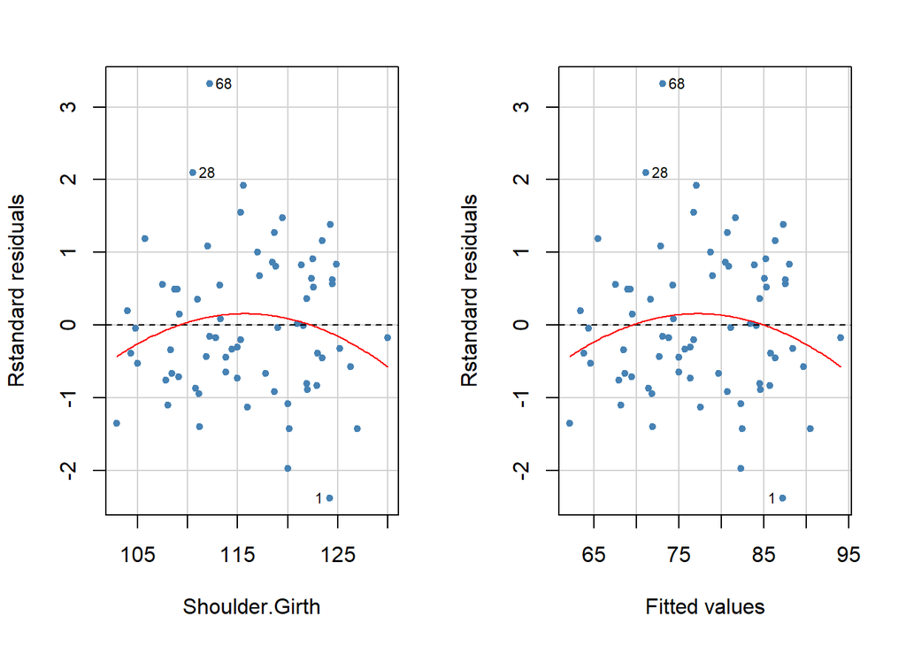

```
##                Test stat Pr(>|Test stat|)
## Shoulder.Girth   -1.2731           0.2074
## Tukey test       -1.2731           0.2030
```

```r
residualPlots(RLS, type = "rstandard",
              id = list(method = "r", n = 3, cex = 0.7, location = "lr"),
              col = "steelblue", pch = 20, col.quad = "red")
```

```r
set.seed(1391)
durbinWatsonTest(RLS)
```

```
##  lag Autocorrelation D-W Statistic p-value
##    1     -0.07873331      2.075621   0.736
##  Alternative hypothesis: rho != 0
```

```r
ncvTest(RLS)
```

```
## Non-constant Variance Score Test
## Variance formula: ~ fitted.values
## Chisquare = 0.04949306, Df = 1, p = 0.82395
```

Al observar el grafico de residuos, se puede notar que no siguen un patrón determinado, lo que sugiere que la distribución de los residuos es aleatoria. La curva roja indica una leve curvatura, pero no es suficiente para rechazar la normalidad de los residuos, además de que la prueba de aditividad de Tukey resulto no significativa con un $p$ de $0.2030$, lo que indica que no hay evidencia suficiente para rechazar la independencia de los datos. Adicionalmente, la prueba de Durbin-Watson da un valor $p$ de $0.736$, lo que indica que no hay evidencia de autocorrelación en los residuos del modelo. Por último, la prueba de homocedasticidad muestra un $p$ de $0.82395$, lo que sugiere que no hay evidencia suficiente para rechazar la hipótesis nula de homocedasticidad.

#### 3. Influencia de Valores Atípicos:

[figure not shown]

```
##       StudRes        Hat      CookD
## 2   0.4278933 0.33145597 0.01313824
## 11 -2.3350984 0.08889943 0.07098822
## 64 -1.7367278 0.23055684 0.12510820
## 68  2.6682640 0.18648508 0.21250896
```

```r
influencePlot(RLM, id = list(cex = 0.7))
```

### Generalidad para el RLM

#### 1. La variable de respuesta debe ser cuantitativa y continua, sin restricciones para su variabilidad:

La variable “Weight” cumple con esta condición, ya que es cuantitativa y continua, representando el peso de los hombres en la muestra.

#### 3. Los predictores deben tener algún grado de variabilidad:

```r
cat("\nVarianza de 'Shoulder.Girth': ", var(data_RLM$Shoulder.Girth))
```

```
##
## Varianza de 'Shoulder.Girth':  44.24452
```

```r
cat("\nVarianza de 'Chest.depth': ", var(data_RLM$Chest.depth))
```

```
##
## Varianza de 'Chest.depth':  3.896996
```

```r
cat("\nVarianza de 'Thigh.Girth': ", var(data_RLM$Thigh.Girth))
```

```
##
## Varianza de 'Thigh.Girth':  17.36317
```

```r
cat("\nVarianza de 'Bitrochanteric.diameter': ", var(data_RLM$Bitrochanteric.diameter))
```

```
##
## Varianza de 'Bitrochanteric.diameter':  3.610592
```

```r
cat("\nVarianza de 'Waist.Girth': ", var(data_RLM$Waist.Girth))
```

```
##
## Varianza de 'Waist.Girth':  72.29772
```

```r
cat("\nVarianza de 'Age': ", var(data_RLM$Age))
```

```
##
## Varianza de 'Age':  94.5882
```

Con este resultado se concluye que los predictores cumplen con la condición de variabilidad, ya que las variables predictoras del modelo RLM planteado tienen varianzas distintas de cero.

A continuación, se realizan gráfico de residuos, gráficos marginales y pruebas de homocedasticidad para verificar las condiciones 4, 5 y 6 de confiabilidad del modelo:

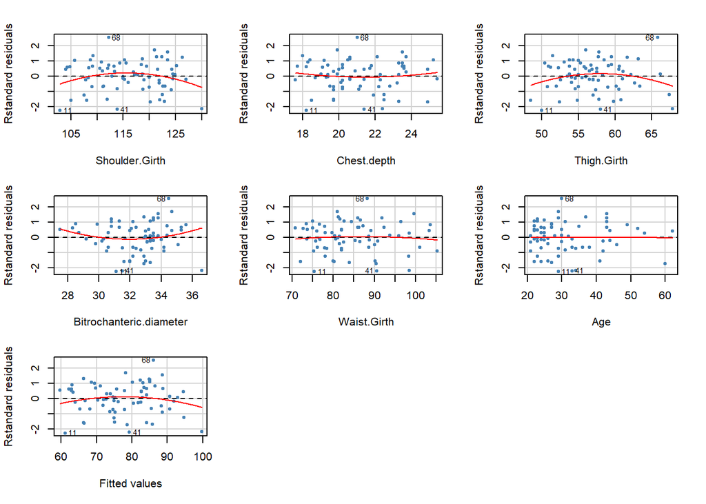

```
##                         Test stat Pr(>|Test stat|)
## Shoulder.Girth            -1.6048           0.1136
## Chest.depth                0.6976           0.4880
## Thigh.Girth               -1.5891           0.1171
## Bitrochanteric.diameter    1.3491           0.1822
## Waist.Girth               -0.4510           0.6536
## Age                       -0.0121           0.9904
## Tukey test                -1.1583           0.2467
```

```r
residualPlots(RLM, type = "rstandard",
              id = list(method = "r", n = 3, cex = 0.7, location = "lr"),
              col = "steelblue", pch = 20, col.quad = "red")
```

```r
cat("\n")
```

```r
ncvTest(RLM)
```

```
## Non-constant Variance Score Test
## Variance formula: ~ fitted.values
## Chisquare = 0.6168685, Df = 1, p = 0.43221
```

#### 4. Cada predictor debe estar relacionado linealmente con la respuesta:

En términos de los gráficos por variable del RLM, observamos que algunos tienen una tendencia lineal sumamente evidente, cómo lo son las variables `Chest.Depth`, `Waist.Girth` y `Age`. En cambio, no es tan sencillo determinar linealidad respecto de la variable de salida para las variables `Bitrochanteric.diameter`, `Shoulder.Girth` y `Thigh.Girth`. Si bien la mitad de las variables están en duda, en base al resultado del test de aditividad de Tukey $Pr(>|TestStatistic) = 0.2467 \geq 0.05$, los datos no presentan la evidencia suficiente para rechazar la condición de relación lineal.

#### 5. La distribución de los residuos debe ser cercana a la normal centrada en cero:

Viendo el gráfico notamos que no sigue un patrón determinado, más aún la curva roja indica una curvatura leve. Observando la aleatoriedad de los puntos en el gráfico, no podemos rechazar la normalidad de los residuos.

#### 6. La variabilidad de los residuos debe ser aproximadamente constante:

La prueba de homocedasticidad da un $p$ de $0.43221$ lo que considerando un nivel de significancia de $0.05$, se concluye que no hay evidencia suficiente para rechazar la hipótesis nula de homocedasticidad, por lo que se considera que la condición de homocedasticidad se cumple.

#### 7. Los residuos deben ser independientes entre sí:

```r
set.seed(1391)
db_test <- durbinWatsonTest(RLM)
print(db_test)
```

```
##  lag Autocorrelation D-W Statistic p-value
##    1      0.01378531      1.961085   0.854
##  Alternative hypothesis: rho != 0
```

Ya que el valor $p$ es de $0.854$, se descarta la presencia de autocorrelación en los residuos del modelo, por lo que no hay evidencia de que no se cumpla la condición de independencia.

#### 8. No debe existir multicolinealidad entre los predictores:

```r
vif_rlm <- vif(RLM)
print(vif_rlm)
```

```
##          Shoulder.Girth             Chest.depth             Thigh.Girth
##                2.300113                2.183908                2.089362
## Bitrochanteric.diameter             Waist.Girth                     Age
##                1.698527                3.463246                1.581341
```

Para cada predictor se obtiene un factor de inflación de varianza menor a 5, entonces se concluye que hay multicolinealidad moderada entre los predictores obtenidos, no obstante, la única variable potencialmente problemática sería `Waist.Girth` pero no es suficientemente alto cómo para llegar a ser preocupante.

#### 9. Las estimaciones de los coeficientes del modelo no deben estar alterados por unas pocas observaciones influyentes:

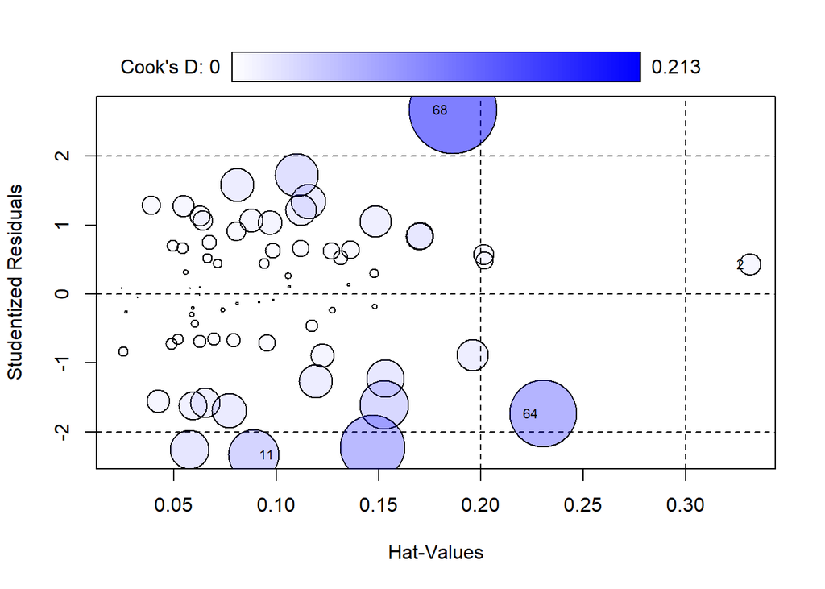

```
##       StudRes        Hat      CookD
## 2   0.4278933 0.33145597 0.01313824
## 11 -2.3350984 0.08889943 0.07098822
## 64 -1.7367278 0.23055684 0.12510820
## 68  2.6682640 0.18648508 0.21250896
```

```r
influencePlot(RLM, id = list(cex = 0.7))
```

El doble del apalancamiento promedio vendría a ser $2\cdot\frac{6+1}{70}=\frac{1}{5} = 0.2$. Notemos que, para los puntos obtenidos, solamente 2 puntos, 2 y 64, no cumplen con la condición de ser menores que el doble del apalancamiento promedio, aun así en vista de los valores correspondientes a la distancia de Cook, siendo estos sumamente bajos y menores que 1, por lo que no deberían influir en la línea de regresión asociada al RLM.

#### Conclusión de condiciones

En retrospectiva el modelo RLM parece ser confiable puesto que se observaron detenidamente las 9 condiciones, y si bien algunas presentan sospechas, no es lo suficientemente significativo cómo para descartar la confiabilidad del modelo.

## Calidad Predictiva

> Una vez vistas las condiciones de cada uno de los modelos confeccionados, se proceden a comparar uno con el otro.

#### Comparación de ANOVA entre RLS y RLM

```r
comparacion_anova <- anova(RLS, RLM)
print(comparacion_anova)
```

```
## Analysis of Variance Table
##
## Model 1: Weight ~ Shoulder.Girth
## Model 2: Weight ~ Shoulder.Girth + Chest.depth + Thigh.Girth + Bitrochanteric.diameter +
##     Waist.Girth + Age
##   Res.Df     RSS Df Sum of Sq      F    Pr(>F)
## 1     68 2694.55
## 2     63  705.83  5    1988.7 35.501 < 2.2e-16 ***
## ---
## Signif. codes:  0 '***' 0.001 '**' 0.01 '*' 0.05 '.' 0.1 ' ' 1
```

Dado que el test de ANOVA entregó un p-value de $2.2 \cdot 10^{-16}$, que implica un cambio sumamente significativo entre el RLS y el RLM, más aún evidenciado por los valores de RSS entregados por el ANOVA.

#### Calidad predictiva para RLS

```r
# conjunto entrenamiento
rls_rmse_entrenamiento <- sqrt(mean(resid(RLS) ** 2))

# Conjunto de prueba
predicciones <- predict(RLS, prueba)
error <- prueba$Weight - predicciones
rls_rmse_prueba <- sqrt(mean(error**2))

# Porcentaje cambio
rls_porcentaje_cambio <- 100*((rls_rmse_prueba - rls_rmse_entrenamiento) / rls_rmse_entrenamiento)
```

#### Calidad predictiva para RLM

```r
# conjunto entrenamiento
rlm_rmse_entrenamiento <- sqrt(mean(resid(RLM) ** 2))

# Conjunto de prueba
predicciones <- predict(RLM, prueba)
error <- prueba$Weight - predicciones
rlm_rmse_prueba <- sqrt(mean(error**2))
# Porcentaje cambio
rlm_porcentaje_cambio <- 100*((rlm_rmse_prueba - rlm_rmse_entrenamiento) / rlm_rmse_entrenamiento)
```

#### Resultados de calidad predictiva de RLS y RLM

```
## Error asociado al conjunto de entrenamiento modelo lineal simple:  6.204316
```

```
## Error asociado al conjunto de entrenamiento modelo lineal múltiple:  3.175428
```

```
## Error asociado al conjunto de prueba modelo lineal simple:  6.421275
```

```
## Error asociado al conjunto de prueba modelo lineal múltiple:  3.807593
```

## Conclusiones

```
## Porcentaje de error para RLS:  3.496892
```

```
## Porcentaje de error para RLM:  19.90801
```

Viendo la diferencia por conjunto, haciendo un antes y un después entre la inserción de las variables predictoras aleatorias, se ve una mejoría en ambos conjuntos evidenciada por la disminución significativa del error. Por lo tanto, el RLM tiene una mejor capacidad predictiva que el RLS. Notar que el modelo RLM no es una mejora directa por sobre el RLS, es importante mencionar el porcentaje de error asociado al RLM, siendo este cercano a $20\%$, mientras que el RLS tiene un porcentaje de error cercano a $3.5\%$, este porcentaje nos indica la fidelidad dentro del dataset del modelo, esto implica que la diferencia entre los valores que ya existen y los generados por el modelo, por tanto el incremento nos indica una desconexión entre la predicción y valores reales, esto indica la presencia de sobreajuste en el RLM que compromete la generalidad frente a nuevos datos. Entonces se debe de continuar con el análisis eliminando posibles predictores que afecten al modelo.